# 用Shiny造一个自己的Wordle网站

Dayu

2022-03-29

# 什么是Wordle

从分类上看，Wordle 和填字游戏都属于字谜游戏的一种。在英语国家，字谜游戏有悠久的历史和广泛的受众，变化也很多样，填字游戏则是其中最具代表性的。

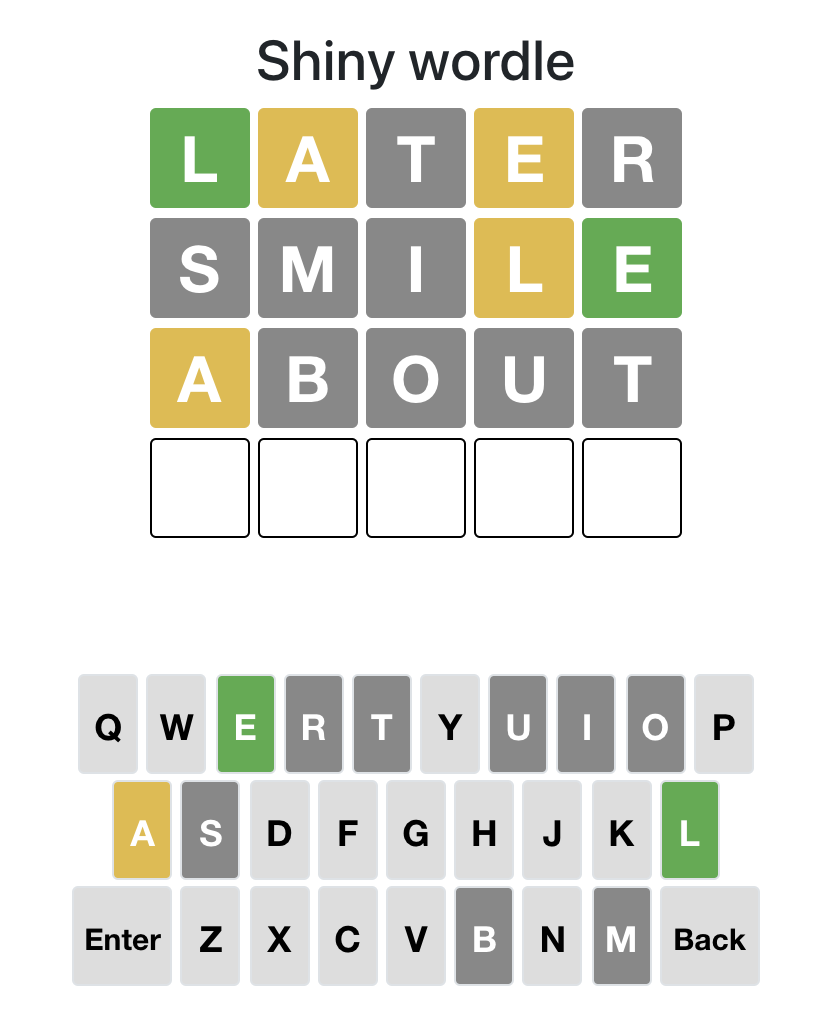

而Wordle在难度和形态上都大大简化：这个游戏每天更新一期，玩家唯一目标，就是在六次尝试机会之内，猜出一个五个字母的单词。

然后，玩家根据获得的提示继续尝试，直到猜对答案，或者用尽六次机会。

Wordle 虽然规则简单，但其实自带了很多促进传播的属性。首先，Wordle 一天只更新一道题目，这种人为制造的稀缺性增强了玩家的挑战欲和期待感。其次，Wordle 的分享功能设计巧妙：用 emoji 色块指代游戏战果，不仅极具辨识度，而且易于传播，又避免了剧透。此外，字谜游戏在欧美国家的传统人气、简单易上手的游戏设计，都一定程度上促进了 Wordle 的火热。

# 用Shiny造一个自己的Wordle网站

通过这篇R-bloggers上的教程就能搭建属于自己的Wordle网站。  
我的成果：https://dayuguo.shinyapps.io/mywordle/

> Reference:
> 1. https://www.r-bloggers.com/2022/03/shiny-wordle-word-journey/